# P4_01_notebook_preprocessing-modelisation

- Transformation du jeu de données
  - Matrice de confusion
  - KPI - Métrique
  - Train Set - Test Set
  - Nettoyage
  - Encodage
  - Preprocessing
    - Première modélisation
  - Feature Engineering
    - Feature Selection
  - Dataset final
  - Rééquilibrage des classes
- Comparaison et synthèse des résultats pour les modèles utilisés
  - Baseline
  - Modélisations
    - Choix des algorithmes
    - Méthodologie
    - RandomForestClassifier
    - LogisticRegression
    - SupportVectorMachine
    - KNearestNeighbors
    - CatBoostClassifier
    - Light Gradient Boosted Machine
  - Le meilleur score
- Interprétabilité du modèle
  - Coût métier
  - SHAP

# 3. Transformation du jeu de données

Ce chapitre a pour objectif de transformer le dataset afin de le mettre dans un format propice au Machine Learning. Plusieurs action sont à effectuer :

- Identification des valeurs manquantes
- Encodage
- Imputation
- Feature selection
- Feature engineering

Tout d'abord nous allons mettre en place les fonctions permettant de traiter les problématiques listées ci-dessus. Ensuite, nous allons les regrouper dans une fonction globale de `preprocessing`, permettant de traiter le jeux de données en amont.

**Table des matières**

```python
import shap
import joblib
from sklearn.metrics import *

from sklearn import preprocessing
from sklearn import model_selection
from sklearn import dummy
from sklearn import impute
from sklearn import metrics
from sklearn import linear_model
from sklearn import svm
from sklearn import ensemble
from sklearn import cluster
from sklearn import decomposition
from sklearn import feature_selection
from sklearn.pipeline import Pipeline
from sklearn.model_selection import GridSearchCV

from imblearn.pipeline import Pipeline as Pipeline_imb
from imblearn import under_sampling
from imblearn import over_sampling

from sklearn.preprocessing import StandardScaler
```

```python
%reload_ext autoreload
from my_functions import *
pd.set_option('display.max_column',122)
```

## 3.1 Matrice de confusion

Comme déjà évoque plus haut, nous allons nous servir de la **matrice de confusion** pour analyser les données plus rapidement et rendre les résultats plus simples.

**Matrice de confusion**

[figure not shown]

Grâce à la comparaison des prédictions aux valeurs réélles, la matrice de confusion permet de comprendre quelles sont les erreurs commises, mais surtout de distinguer le type d’erreurs. Les voilà :

- **True Positive (TP)** : la prédiction et la valeur réelle sont positives. ** Ici : un refus de crédit car le client n'est pas solvable
- **True Negative (TN)** : la prédiction et la valeur réelle sont négatives. ** Ici : une acceptation de crédit car le client est solvable
- **False Positive (FP)** : la prédiction est positive alors que la valeur réelle est négative. ** Ici : un refus de crédit alors que le client est solvable
- **False Negative (FN)** : la prédiction est négative alors que la valeur réelle est positive. ** Ici : une acceptation de crédit alors que le client n'est pas solvable.

Notre objectif est donc de détecter deux cas de figure :

## 3.2 KPI - Métriques

Afin de répondre à nos objectifs, nous allons nous appuyer sur les mesures de performance suivantes :

- Precision - permet de savoir combien de prédictions vraies étaient réellement vraies
- Sensibilité (Recall) - permet de savoir, pour les prédictions rééllement vraies, combien de fois le modèle s'est trompé
- `roc_auc`- permet de visualiser comment évolue la sensibilité et la spécificité d'un modèle

**Calculer les mesures de performance : Precision & Recall**

[figure not shown]

([source](https://www.youtube.com/watch?v=Clo-t9eeEwg))

## 3.3 Train Set - Test Set

#### Data leakage

Afin d'éviter la "fuite d'informations" entre le jeu de données d'entraînement et de test, nous allons maintenant séparer notre jeu de données en deux. Les transformations seront apprises uniquement sur le jeu d'entraînement, mais appliquées aux deux jeux de données (entraînement et test).

```python
# Chargement du jeu de données
data = joblib.load('df_clean_eda')
```

```python
data.shape
```

```
(380713, 51)
```

```python
# Sampling du jeu de données : 40% sera utilisé par la suite
data = data.sample(frac=0.40, random_state=1)
```

```python
data.shape
```

```
(152285, 51)
```

```python
data.head()
```

|  | TARGET | NAME_CONTRACT_TYPE | CODE_GENDER | FLAG_OWN_CAR | FLAG_OWN_REALTY | CNT_CHILDREN | AMT_INCOME_TOTAL | AMT_CREDIT | AMT_ANNUITY_x | AMT_GOODS_PRICE | NAME_INCOME_TYPE | NAME_EDUCATION_TYPE | NAME_FAMILY_STATUS | NAME_HOUSING_TYPE | DAYS_BIRTH | DAYS_EMPLOYED | FLAG_MOBIL | FLAG_EMP_PHONE | FLAG_WORK_PHONE | FLAG_CONT_MOBILE | FLAG_PHONE | FLAG_EMAIL | OCCUPATION_TYPE | CNT_FAM_MEMBERS | REGION_RATING_CLIENT | REGION_RATING_CLIENT_W_CITY | REG_REGION_NOT_LIVE_REGION | REG_CITY_NOT_WORK_CITY | LIVE_CITY_NOT_WORK_CITY | … |
| --- | --- | --- | --- | --- | --- | --- | --- | --- | --- | --- | --- | --- | --- | --- | --- | --- | --- | --- | --- | --- | --- | --- | --- | --- | --- | --- | --- | --- | --- | --- |
| 2923986 | 0 | Cash loans | F | N | N | 0 | 126000.0 | 1078200.0 | 31522.5 | 900000.0 | Working | Higher education | Married | House / apartment | 37.947945 | 1932.0 | 1 | 1 | 0 | 1 | 1 | 0 | Laborers | 2.0 | 2 | 2 | 0 | 0 | 0 | … |
| 3296805 | 0 | Cash loans | F | N | Y | 1 | 193500.0 | 891072.0 | 45625.5 | 720000.0 | State servant | Secondary / secondary special | Married | House / apartment | 34.405479 | 3627.0 | 1 | 1 | 0 | 1 | 0 | 0 | NaN | 3.0 | 2 | 2 | 0 | 0 | 0 | … |
| 1482901 | 0 | Cash loans | F | N | Y | 0 | 270000.0 | 408780.0 | 23598.0 | 337500.0 | Working | Secondary / secondary special | Single / not married | House / apartment | 37.515068 | 2337.0 | 1 | 1 | 0 | 1 | 0 | 0 | Sales staff | 1.0 | 1 | 1 | 0 | 0 | 0 | … |
| 929589 | 0 | Cash loans | F | N | Y | 0 | 121500.0 | 599778.0 | 32665.5 | 477000.0 | Commercial associate | Secondary / secondary special | Widow | House / apartment | 54.534247 | 3953.0 | 1 | 1 | 0 | 1 | 0 | 0 | High skill tech staff | 1.0 | 2 | 2 | 0 | 0 | 0 | … |
| 1841279 | 0 | Cash loans | M | Y | Y | 3 | 157500.0 | 168102.0 | 13410.0 | 148500.0 | Working | Secondary / secondary special | Married | Municipal apartment | 37.323288 | 1105.0 | 1 | 1 | 0 | 1 | 0 | 0 | Laborers | 5.0 | 2 | 2 | 0 | 0 | 0 | … |

Séparons nos données en un jeu d’entraînement et un jeu de test. Le jeu de test contiendra 20% des données :

```python
from sklearn.model_selection import train_test_split
```

```python
trainset, testset = train_test_split(data, test_size=0.2, random_state=0)
```

Vérification de la répartition des valeurs cibles de la variable `TARGET` dans les deux jeux de données :

```python
counter(trainset['TARGET'])
```

```
Class = 0, n = 113203 (92.9203467183242%)
Class = 1, n = 8625 (7.079653281675805%)
```

```python
counter(testset['TARGET'])
```

```
Class = 0, n = 28271 (92.82266802377121%)
Class = 1, n = 2186 (7.177331976228782%)
```

Le jeu de données a été divisé en deux parties :

- training : 80% de données
- validation : 20% de données

## 3.4 Nettoyage

### Identification des valeurs manquantes.

Identifions les variables qui contiennent les valeurs manquantes.

```python
# Missing values statistics
missing_values = missing_values_table(trainset)
missing_values.head(30)
```

```
Nombre de colonnes dans le dataset 51
18 colonnes contenant des NaN.
```

|  | Missing Values | % of Total Values |
| --- | --- | --- |
| EXT_SOURCE_1 | 63348 | 52.0 |
| DAYS_ENDDATE_FACT | 44687 | 36.7 |
| AMT_CREDIT_SUM_LIMIT | 41455 | 34.0 |
| OCCUPATION_TYPE | 34683 | 28.5 |
| AMT_CREDIT_SUM_DEBT | 19077 | 15.7 |
| DAYS_EMPLOYED | 18454 | 15.1 |
| CNT_INSTALMENT_MATURE_CUM | 16258 | 13.3 |
| DAYS_CREDIT_ENDDATE | 7648 | 6.3 |
| AMT_BALANCE | 6282 | 5.2 |
| SK_DPD | 6282 | 5.2 |
| NAME_CONTRACT_STATUS | 6282 | 5.2 |
| AMT_CREDIT_LIMIT_ACTUAL | 6282 | 5.2 |
| SK_DPD_DEF | 6282 | 5.2 |
| MONTHS_BALANCE | 6282 | 5.2 |
| EXT_SOURCE_3 | 3005 | 2.5 |
| EXT_SOURCE_2 | 53 | 0.0 |
| AMT_ANNUITY_x | 12 | 0.0 |
| AMT_GOODS_PRICE | 8 | 0.0 |

- remplir les valeurs manquantes
- supprimer les colonnes dont le taux de valeurs manquantes est très élevé

Nous n'allons supprimer aucune feature, en revanche nous allons traiter les valeurs manquantes. Nous allons procéder par type de données :

- variables catégorielles
- variables numériques

### Variables catégorielles. Imputation par mode.

Identifions les colonnes concernées :

```python
trainset.select_dtypes(include="object").isna().sum()/len(trainset)*100
```

```
NAME_CONTRACT_TYPE       0.000000
CODE_GENDER              0.000000
FLAG_OWN_CAR             0.000000
FLAG_OWN_REALTY          0.000000
NAME_INCOME_TYPE         0.000000
NAME_EDUCATION_TYPE      0.000000
NAME_FAMILY_STATUS       0.000000
NAME_HOUSING_TYPE        0.000000
OCCUPATION_TYPE         28.468825
ORGANIZATION_TYPE        0.000000
CREDIT_ACTIVE            0.000000
CREDIT_TYPE              0.000000
NAME_CONTRACT_STATUS     5.156450
dtype: float64
```

Afin de traiter les valeurs manquantes, nous allons **procéder à un remplissage**. Après l'analyse des modalités de chaque variable, le **mode** semble être la meilleure option. Ci-dessous une liste de variables à remplir :

```python
# Liste de variables à traiter
list_cat_nan = ['OCCUPATION_TYPE','NAME_CONTRACT_STATUS']
```

Mettons en place une fonction permettant un remplissage par mode :

```python
def imputation_mode (df) :
    for ft in list_cat_nan :
        df[ft].fillna(df[ft].mode()[0], inplace=True)
        #print ("Traitement de la variable : ",ft, " - DONE")
    return df
```

### Variables numériques. Imputation par médiane.

**Choix de la stratégie d'imputation**

Il existe plusieurs transformateurs d'imputation dans le module `Impute de sklearn` :

- **SimpleImputer()**
  - remplace les valeurs manquantes par une valeur statistique :
    - mean
    - median
    - most_frequent
    - constant
- **IterativeImputer()**
- **MissingIndicator()**
  - indique l'absence de valeurs dans le dataset
- **KNNImputer()**
  - remplace les valeurs manquantes par les valeurs des plus proches voisins

Identifions les variables numériques à traiter :

```python
trainset.select_dtypes(include=np.number).isna().sum().sort_values(ascending=False).head(30)/ len(trainset) * 100
```

```
EXT_SOURCE_1                   51.997899
DAYS_ENDDATE_FACT              36.680402
AMT_CREDIT_SUM_LIMIT           34.027481
AMT_CREDIT_SUM_DEBT            15.658962
DAYS_EMPLOYED                  15.147585
CNT_INSTALMENT_MATURE_CUM      13.345044
DAYS_CREDIT_ENDDATE             6.277703
MONTHS_BALANCE                  5.156450
SK_DPD_DEF                      5.156450
AMT_BALANCE                     5.156450
AMT_CREDIT_LIMIT_ACTUAL         5.156450
SK_DPD                          5.156450
EXT_SOURCE_3                    2.466592
EXT_SOURCE_2                    0.043504
AMT_ANNUITY_x                   0.009850
AMT_GOODS_PRICE                 0.006567
AMT_CREDIT_SUM                  0.000000
CNT_CREDIT_PROLONG              0.000000
CREDIT_DAY_OVERDUE              0.000000
DAYS_CREDIT                     0.000000
AMT_CREDIT_SUM_OVERDUE          0.000000
TARGET                          0.000000
CNT_CHILDREN                    0.000000
REG_CITY_NOT_WORK_CITY          0.000000
REG_REGION_NOT_LIVE_REGION      0.000000
REGION_RATING_CLIENT_W_CITY     0.000000
REGION_RATING_CLIENT            0.000000
CNT_FAM_MEMBERS                 0.000000
FLAG_EMAIL                      0.000000
FLAG_PHONE                      0.000000
dtype: float64
```

Suite à l'analyse des variables, nous constatons que c'est le **remplissage par médiane** qui donnera les meilleurs résultats.

La méthode des plus proches voisins n'a pas vraiment de sens vu la nature des données. De plus, nous avons remarqué **la présence des outliers**, ce qui écarte la piste d'imputation par moyenne (la moyenne étant très sensible aux valeurs aberrantes).

Nous allons donc opter pour **l'imputation par médiane**.

```python
# Fonction d'imputation par médiane
def imputation_median(df):
    imputer = SimpleImputer(strategy = 'median', missing_values=np.nan)
    imputer.fit(df)

    # Transform both training and testing data
    df = pd.DataFrame(imputer.transform(df.loc[:,:]),
                      columns = df.columns)
    return df
```

## 3.5 Encodage

Avant d'entraîner le dataset, nous devons nous assurer que toute variable catégorielle est transformée en une variable numérique.

Pour ce faire, il existe plusieurs transformateurs d'encodage dans le module `preprocessing de sklearn` :

**Encodage One Hot => chaque catégorie ou classe est représentée de façon binaire dans une colonne qui lui est propre**

- LabelBinarizer()
  - encode chaque classe de la variable `y` en One Hot
- MultiLabelBinarizer()
- OneHotEncoder()
  - encode les catégories des variables `X` en One Hot

**Encodage ordinal => associe chaque catégorie ou classe d'une variable à une valeur décimale unique**

- LabelEncoder()
  - encode chaque classe de la variable `y` en une valeur numérique
- OrdinalEncoder()
  - conçu pour traiter plusieurs variables

### Encodage : variables à deux modalités.

Etant donné la présence de variables catégorielles ayant **deux modalités**, nous avons décidé de les traiter manuellement. Nous allons créer une fonction remplaçant les variables de type `object` en des `int`.

Ci-dessous une liste de modalités par variable catégorielle.

```python
for key, value in trainset.select_dtypes('object').iteritems():
    print("{} -----------------------> {}".format(key,trainset[key].unique()))
```

```
NAME_CONTRACT_TYPE -----------------------> ['Cash loans' 'Revolving loans']
CODE_GENDER -----------------------> ['M' 'F']
FLAG_OWN_CAR -----------------------> ['N' 'Y']
FLAG_OWN_REALTY -----------------------> ['Y' 'N']
NAME_INCOME_TYPE -----------------------> ['Commercial associate' 'Working' 'State servant' 'Pensioner' 'Student']
NAME_EDUCATION_TYPE -----------------------> ['Secondary / secondary special' 'Higher education' 'Incomplete higher'
 'Lower secondary' 'Academic degree']
NAME_FAMILY_STATUS -----------------------> ['Married' 'Separated' 'Single / not married' 'Widow' 'Civil marriage']
NAME_HOUSING_TYPE -----------------------> ['House / apartment' 'With parents' 'Municipal apartment'
 'Rented apartment' 'Office apartment' 'Co-op apartment']
OCCUPATION_TYPE -----------------------> ['Laborers' 'Core staff' 'Managers' nan 'High skill tech staff' 'HR staff'
 'Medicine staff' 'Drivers' 'Cooking staff' 'Security staff' 'Accountants'
 'Sales staff' 'Secretaries' 'Cleaning staff' 'Private service staff'
 'Realty agents' 'Waiters/barmen staff' 'IT staff' 'Low-skill Laborers']
ORGANIZATION_TYPE -----------------------> ['Business Entity Type 3' 'Kindergarten' 'School' 'Business Entity Type 1'
 'Industry: type 9' 'Medicine' 'Self-employed' 'Transport: type 4'
 'Government' 'Transport: type 2' 'Other' 'Security' 'Construction' 'Bank'
 'Industry: type 7' 'Industry: type 11' 'Business Entity Type 2' 'Culture'
 'Security Ministries' 'Industry: type 1' 'Transport: type 3'
 'Industry: type 5' 'Trade: type 3' 'Agriculture' 'Police' 'Military'
 'Services' 'Industry: type 3' 'Legal Services' 'Restaurant'
 'Trade: type 7' 'Trade: type 1' 'Housing' 'Realtor' 'Postal' 'University'
 'Trade: type 5' 'Transport: type 1' 'Industry: type 4' 'Hotel'
 'Trade: type 6' 'Trade: type 2' 'Insurance' 'Industry: type 10'
 'Electricity' 'Advertising' 'Industry: type 13' 'Mobile' 'Cleaning'
 'Telecom' 'Trade: type 4' 'Industry: type 2' 'Emergency'
 'Industry: type 6' 'Industry: type 8' 'Industry: type 12' 'Religion']
CREDIT_ACTIVE -----------------------> ['Closed' 'Active' 'Sold']
CREDIT_TYPE -----------------------> ['Consumer credit' 'Credit card' 'Microloan' 'Car loan' 'Mortgage'
 'Loan for business development' 'Loan for working capital replenishment'
 'Another type of loan' 'Loan for the purchase of equipment'
 'Unknown type of loan' 'Cash loan (non-earmarked)']
NAME_CONTRACT_STATUS -----------------------> ['Active' nan 'Completed' 'Signed' 'Sent proposal' 'Demand']
```

Notre objectif est de traiter les variables suivantes :

```python
trainset.FLAG_OWN_CAR.unique(), trainset.FLAG_OWN_REALTY.unique()
```

```
(array(['N', 'Y'], dtype=object), array(['Y', 'N'], dtype=object))
```

Ci-dessous la fonction permettant de remplacer les valeurs catégorielles par celles numériques :

```python
def encodage_binaire (df) :
    code_binaire= {'Y':1,
                  'N':0,
                  'Yes':1,
                  'No':0}
    for ft in df.select_dtypes('object'):
        df.loc[:,ft]=df[ft].replace(code_binaire)

    return df
```

Vérification des types de données avant l'exécution de la fonction :

```python
trainset.dtypes.value_counts()
```

```
float64    23
int64      15
object     13
dtype: int64
```

### One Hot Encoding

Pour les autres variables catégorielles, nous allons appliquer le **One Hot Encoding** en nous servant de la fonction `get_dummies()` de `pandas`.

```python
# One-hot encoding of categorical variables

def encodage_one_hot(df):
    df = pd.get_dummies(df)

    return df
    print('Features shape: ', df.shape)
```

A présent, nous allons exécuter toutes les fonctions développées. Pour cela, nous allons les regrouper dans une nouvelle fonction : `preprocessing`.

## 3.6 Preprocessing

La fonction `preprocessing` a pour but d'effectuer les modifications suivantes :

1. Remplacer les valeurs `Y`, `N` par des `0` et `1`
2. Remplacer les valeurs NAN des variables catégorielles via la stratégie de remplissage par le `mode`.
3. Créer de nouvelles variables via le `One Hot Encoding`.
4. Remplacer les valeurs NAN des variables numériques via la stratégie de remplissage par la `médiane`.

Avant, un coup d'oeil rapide sur les dimensions de nos datasets :

```python
shape_check(trainset, testset)
```

```
Training set shape :  (121828, 51)
Testing set shape :  (30457, 51)
```

```python
def preprocessing(df):

    df = encodage_binaire(df)
    df = imputation_mode(df)
    df = encodage_one_hot(df)
    df = imputation_median(df)

    X = df.drop(["TARGET"], axis=1)
    y = df["TARGET"]

    print(y.value_counts(normalize=True))

    return X, y
```

#### Séparation target - features

Une fois le jeu de données transformé, nous allons isoler la variable cible dans les deux jeux de données : le train et le test.

```python
X_train, y_train = preprocessing(trainset)
```

```
0.0    0.929203
1.0    0.070797
Name: TARGET, dtype: float64
```

```python
X_test, y_test = preprocessing(testset)
```

```
0.0    0.928227
1.0    0.071773
Name: TARGET, dtype: float64
```

```python
shape_check(X_train, X_test)
```

```
Training set shape :  (121828, 158)
Testing set shape :  (30457, 157)
```

```python
shape_check(y_train, y_test)
```

```
Training set shape :  (121828,)
Testing set shape :  (30457,)
```

Attention, la variable cible TARGET est très déséquilibrée ! Nous avons presque 93% de valeurs de la classe 0 (client solvable) contre seulement 7% de valeurs de la classe 1 (client risqué).

Plus loin, nous allons procéder à un rééquilibrage.

### Vérification des résultats du preprocessing

Suite au préprocessing, notre dataset est transformé. Vérifions si la transformation s'est passée comme prévu :

**1. Affichage du training set**

```python
X_train.head()
```

|  | FLAG_OWN_CAR | FLAG_OWN_REALTY | CNT_CHILDREN | AMT_INCOME_TOTAL | AMT_CREDIT | AMT_ANNUITY_x | AMT_GOODS_PRICE | DAYS_BIRTH | DAYS_EMPLOYED | FLAG_MOBIL | FLAG_EMP_PHONE | FLAG_WORK_PHONE | FLAG_CONT_MOBILE | FLAG_PHONE | FLAG_EMAIL | CNT_FAM_MEMBERS | REGION_RATING_CLIENT | REGION_RATING_CLIENT_W_CITY | REG_REGION_NOT_LIVE_REGION | REG_CITY_NOT_WORK_CITY | LIVE_CITY_NOT_WORK_CITY | EXT_SOURCE_1 | EXT_SOURCE_2 | EXT_SOURCE_3 | DAYS_CREDIT | CREDIT_DAY_OVERDUE | DAYS_CREDIT_ENDDATE | DAYS_ENDDATE_FACT | CNT_CREDIT_PROLONG | … |
| --- | --- | --- | --- | --- | --- | --- | --- | --- | --- | --- | --- | --- | --- | --- | --- | --- | --- | --- | --- | --- | --- | --- | --- | --- | --- | --- | --- | --- | --- | --- |
| 0 | 0.0 | 1.0 | 0.0 | 157500.0 | 1082214.0 | 31770.0 | 945000.0 | 54.432877 | 2630.0 | 1.0 | 1.0 | 0.0 | 1.0 | 0.0 | 0.0 | 2.0 | 2.0 | 2.0 | 0.0 | 0.0 | 0.0 | 0.562626 | 0.670557 | 0.501075 | 2483.0 | 0.0 | -2147.0 | -2176.0 | 0.0 | … |
| 1 | 1.0 | 1.0 | 3.0 | 135000.0 | 444420.0 | 26986.5 | 337500.0 | 33.778082 | 304.0 | 1.0 | 1.0 | 0.0 | 1.0 | 0.0 | 0.0 | 5.0 | 2.0 | 2.0 | 0.0 | 0.0 | 0.0 | 0.562626 | 0.632805 | 0.431192 | 361.0 | 0.0 | 732.0 | -951.0 | 0.0 | … |
| 2 | 0.0 | 1.0 | 0.0 | 130500.0 | 148500.0 | 16123.5 | 148500.0 | 37.041096 | 5488.0 | 1.0 | 1.0 | 0.0 | 1.0 | 0.0 | 0.0 | 2.0 | 2.0 | 2.0 | 0.0 | 0.0 | 0.0 | 0.103595 | 0.355847 | 0.479449 | 1215.0 | 0.0 | -119.0 | -1026.0 | 0.0 | … |
| 3 | 0.0 | 1.0 | 0.0 | 247500.0 | 797818.5 | 40864.5 | 634500.0 | 43.219178 | 3022.0 | 1.0 | 1.0 | 1.0 | 1.0 | 1.0 | 1.0 | 1.0 | 2.0 | 2.0 | 0.0 | 0.0 | 0.0 | 0.816152 | 0.694765 | 0.812823 | 1872.0 | 0.0 | -46.0 | -67.0 | 0.0 | … |
| 4 | 0.0 | 1.0 | 0.0 | 121500.0 | 1262583.0 | 36315.0 | 1102500.0 | 57.189041 | 13977.0 | 1.0 | 1.0 | 1.0 | 1.0 | 1.0 | 0.0 | 2.0 | 3.0 | 3.0 | 0.0 | 1.0 | 1.0 | 0.562626 | 0.360482 | 0.614414 | 747.0 | 0.0 | 1079.0 | -951.0 | 0.0 | … |

5 rows × 158 columns

```python
X_train.shape
```

```
(121828, 158)
```

**Remarques**

- L'encodage One Hot Encoding a fonctionné, le nombre de variables est passé de 51 à 158 !
- Nous remarquons l'absence de la variable `TARGET`.

**2. Affichage du testing set**

```python
X_test.head()
```

|  | FLAG_OWN_CAR | FLAG_OWN_REALTY | CNT_CHILDREN | AMT_INCOME_TOTAL | AMT_CREDIT | AMT_ANNUITY_x | AMT_GOODS_PRICE | DAYS_BIRTH | DAYS_EMPLOYED | FLAG_MOBIL | FLAG_EMP_PHONE | FLAG_WORK_PHONE | FLAG_CONT_MOBILE | FLAG_PHONE | FLAG_EMAIL | CNT_FAM_MEMBERS | REGION_RATING_CLIENT | REGION_RATING_CLIENT_W_CITY | REG_REGION_NOT_LIVE_REGION | REG_CITY_NOT_WORK_CITY | LIVE_CITY_NOT_WORK_CITY | EXT_SOURCE_1 | EXT_SOURCE_2 | EXT_SOURCE_3 | DAYS_CREDIT | CREDIT_DAY_OVERDUE | DAYS_CREDIT_ENDDATE | DAYS_ENDDATE_FACT | CNT_CREDIT_PROLONG | … |
| --- | --- | --- | --- | --- | --- | --- | --- | --- | --- | --- | --- | --- | --- | --- | --- | --- | --- | --- | --- | --- | --- | --- | --- | --- | --- | --- | --- | --- | --- | --- |
| 0 | 1.0 | 1.0 | 0.0 | 292500.0 | 630000.0 | 42232.5 | 630000.0 | 33.032877 | 3146.0 | 1.0 | 1.0 | 0.0 | 1.0 | 0.0 | 0.0 | 2.0 | 2.0 | 2.0 | 0.0 | 1.0 | 1.0 | 0.565970 | 0.492174 | 0.448962 | 919.0 | 0.0 | 171.0 | -959.0 | 0.0 | … |
| 1 | 1.0 | 1.0 | 2.0 | 157500.0 | 545040.0 | 26509.5 | 450000.0 | 48.380822 | 6189.0 | 1.0 | 1.0 | 0.0 | 1.0 | 0.0 | 0.0 | 4.0 | 2.0 | 2.0 | 0.0 | 0.0 | 0.0 | 0.605981 | 0.663666 | 0.206779 | 840.0 | 0.0 | 983.0 | -959.0 | 0.0 | … |
| 2 | 0.0 | 1.0 | 0.0 | 315000.0 | 501435.0 | 19030.5 | 414000.0 | 41.868493 | 5539.0 | 1.0 | 1.0 | 0.0 | 1.0 | 0.0 | 0.0 | 2.0 | 3.0 | 3.0 | 0.0 | 0.0 | 0.0 | 0.565970 | 0.627392 | 0.537070 | 1059.0 | 0.0 | -355.0 | -959.0 | 0.0 | … |
| 3 | 0.0 | 0.0 | 0.0 | 180000.0 | 1288350.0 | 37795.5 | 1125000.0 | 51.424658 | 10958.0 | 1.0 | 1.0 | 0.0 | 1.0 | 0.0 | 0.0 | 2.0 | 2.0 | 2.0 | 0.0 | 0.0 | 0.0 | 0.565970 | 0.537021 | 0.502878 | 570.0 | 0.0 | 516.0 | -959.0 | 0.0 | … |
| 4 | 1.0 | 0.0 | 0.0 | 225000.0 | 545040.0 | 36423.0 | 450000.0 | 51.115068 | 799.0 | 1.0 | 1.0 | 1.0 | 1.0 | 1.0 | 0.0 | 2.0 | 2.0 | 2.0 | 0.0 | 0.0 | 0.0 | 0.565970 | 0.376741 | 0.520898 | 735.0 | 0.0 | -385.0 | -959.0 | 0.0 | … |

5 rows × 157 columns

```python
X_test.shape
```

```
(30457, 157)
```

**Remarques**

- Attention, le nombre de colonnes dans le testing set est différent de celui dans le training set ! 157 vs 158.
- Cela est dû au One Hot Encoding, qui a créé plus de colonnes dans le train set car il y eu des variables catégorielles dont les modalités n'étaient pas représentées dans le testing set.
- Par conséquent, il est nécessaire de procéder à un alignement, les dataframes doivent avoir les mêmes dimensions.

#### Alignement Training et Testing Data

```python
# Align the training and testing data, keep only columns present in both dataframes
X_train, X_test = X_train.align(X_test, join = 'inner', axis = 1)
```

```python
shape_check(X_train, X_test)
```

```
Training set shape :  (121828, 157)
Testing set shape :  (30457, 157)
```

**3. Vérification si présence des valeurs manquantes au sein des variables catégorielles**

```python
print("NaN dans le training dataset : ",X_train.select_dtypes(include="object").isna().sum())
print("NaN dans le testing dataset : ",X_test.select_dtypes(include="object").isna().sum())
```

```
NaN dans le training dataset :  Series([], dtype: float64)
NaN dans le testing dataset :  Series([], dtype: float64)
```

**4. Vérification si l'encodage manuel a fonctionné**

```python
X_train.FLAG_OWN_CAR.unique(), X_train.FLAG_OWN_REALTY.unique(), X_test.FLAG_OWN_CAR.unique(), X_test.FLAG_OWN_REALTY.unique()
```

```
(array([0., 1.]), array([1., 0.]), array([1., 0.]), array([1., 0.]))
```

**5. Vérification si les types de données ont changé**

```python
X_train.dtypes.value_counts()
```

```
float64    157
dtype: int64
```

```python
X_test.dtypes.value_counts()
```

```
float64    157
dtype: int64
```

**Remarque**

- Actuellement, le dataset contient uniquement des valeurs numériques, suite à l'encodage.

**6. Vérification si présence de valeurs manquantes au sein des variables numériques**

```python
X_train.select_dtypes(include=np.number).isna().sum().sum()
```

```
0
```

```python
X_test.select_dtypes(include=np.number).isna().sum().sum()
```

```
0
```

## Première modélisation

Nous allons effectuer une première tentative de modélisation avec une première version du jeu de données. Pour cela, nous allons utiliser le modèle `DecisionTreeClassifier()` avec les paramètres suivants :

- la métrique adoptée est le `roc_auc`
- l'option `class_weight = "balanced"` est activée

Le résultat montrera :

- une matrice de confusion
- la courbe ROC
- la learning curve

**Modélisation n°1 : premier essai**

```python
first_model = DecisionTreeClassifier(class_weight = "balanced", random_state=0)
```

```python
def evaluation(model, train, test, y1=y_train, y2=y_test):

    model.fit(train, y1)
    y_pred = model.predict(test)

# Matrice de confusion
    print("------------------------- 1. Matrice de confusion -------------------------------------------\n")
    print(confusion_matrix(y2, y_pred))
    print("\n")
    print(classification_report(y2, y_pred))


# Dessiner la courbe ROC
    print("\n------------------------- 2. Courbe ROC : -------------------------------------------\n")

    fpr, tpr, thr = roc_curve(y2, y_pred)
    roc_auc = auc(fpr, tpr)

    plt.figure(figsize=(10,10))
    plt.title('Receiver Operating Characteristic')
    plt.plot(fpr, tpr, color='red',label = 'AUC = %0.2f' % roc_auc)
    plt.legend(loc = 'lower right')

    plt.plot([0, 1], [0, 1],linestyle='--')
    plt.axis('tight')
    plt.ylabel('True Positive Rate')
    plt.xlabel('False Negative Rate')
    plt.grid()
    plt.show()
    print("L'aire sous la courbe ROC : ", roc_auc)

    print("\n------------------------- 3. Learning curve : -------------------------------------------\n")
# Check learning curve
    N, train_score, val_score = learning_curve(model, train, y1,
                                              cv=4, scoring='roc_auc',
                                               train_sizes=np.linspace(0.1, 1, 10))


    plt.figure(figsize=(12, 8))
    plt.plot(N, train_score.mean(axis=1), label='Train score')
    plt.plot(N, val_score.mean(axis=1), label='Validation score')
    plt.xlabel("Experience")
    plt.ylabel("Apprentissage")
    plt.legend()
    plt.grid()
```

```
------------------------- 1. Matrice de confusion -------------------------------------------

[[27998   273]
 [  406  1780]]


              precision    recall  f1-score   support

         0.0       0.99      0.99      0.99     28271
         1.0       0.87      0.81      0.84      2186

    accuracy                           0.98     30457
   macro avg       0.93      0.90      0.91     30457
weighted avg       0.98      0.98      0.98     30457


------------------------- 2. Courbe ROC : -------------------------------------------
```

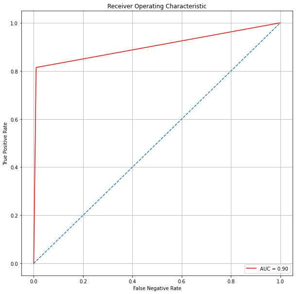

```
L'aire sous la courbe ROC :  0.9023080527982291

------------------------- 3. Learning curve : -------------------------------------------
```

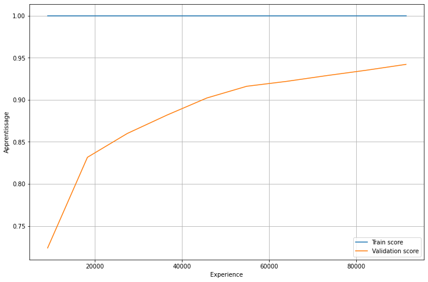

```python
evaluation(first_model, X_train, X_test)
```

**Commentaire :**

1. Les données du jeu d'entraînement suivent la courbe d'apprentissage à 100%. L'entraînement se passe très bien.
2. Les données du jeu de validation progressent avec le nombre d'échantillons fournis à l'apprentissage.
3. Les deux courbes se rapprochent, le modèle est donc capable de généraliser.

**Résultats :**

Un très bon résultat pour une première évaluation.

## 3.7 Feature Engineering

### Variables métier

L'objectif de ce chapitre est de créer de nouvelles features permettant une meilleure compréhension.

Il pourrait être intéressant d'étudier de plus près les variables de type `AMT_`. Leur combinaison pourrait apporter plus de sens aux données que nous allons fournir aux modèles, mais également apporter des informations supplémentaires en relation avec la variable `TARGET`.

L'idée est de créer de nouvelles features qui peuvent nous indiquer des informations importantes afin de prédire si un client risque d'avoir des problèmes de remboursement ou non.

Les informations métier dont le jeu de données ne dispose pas sont :

- Ratio **montant emprunté** vs **prix du bien acheté** : AMT_CREDIT / AMT_GOODS_PRICE
- Ratio **annuités** vs **montant emprunté** : AMT_ANNUITY / AMT_CREDIT
- Ratio **annuités** vs **revenus annuels** : AMT_ANNUITY / AMT_INCOME_TOTAL
- Ratio **ancienneté au travail** vs **âge** : DAYS_EMPLOYED / DAYS_BIRTH

Ci-dessous une fonction permettant de créer les nouvelles features :

```python
def feature_engineering(df):
    df["CREDIT_PRICE_RATIO"] = df["AMT_CREDIT"] / df["AMT_GOODS_PRICE"]
    df["ANNUITY_CREDIT_RATIO"] = df["AMT_ANNUITY_x"] / df["AMT_CREDIT"]
    df["ANNUITY_INCOME_RATIO"] = df["AMT_ANNUITY_x"] / df["AMT_INCOME_TOTAL"]
    df["EMPLOYED_BIRTH_RATIO"] = df["DAYS_EMPLOYED"] / df["DAYS_BIRTH"]
    return df
```

```python
X_train = feature_engineering(X_train)
```

```python
X_test = feature_engineering(X_test)
```

```python
shape_check(X_train, X_test)
```

```
Training set shape :  (121828, 161)
Testing set shape :  (30457, 161)
```

Relançons notre modèle suite à la création de nouvelles features :

```python
X_train.head(2)
```

|  | FLAG_OWN_CAR | FLAG_OWN_REALTY | CNT_CHILDREN | AMT_INCOME_TOTAL | AMT_CREDIT | AMT_ANNUITY_x | AMT_GOODS_PRICE | DAYS_BIRTH | DAYS_EMPLOYED | FLAG_MOBIL | FLAG_EMP_PHONE | FLAG_WORK_PHONE | FLAG_CONT_MOBILE | FLAG_PHONE | FLAG_EMAIL | CNT_FAM_MEMBERS | REGION_RATING_CLIENT | REGION_RATING_CLIENT_W_CITY | REG_REGION_NOT_LIVE_REGION | REG_CITY_NOT_WORK_CITY | LIVE_CITY_NOT_WORK_CITY | EXT_SOURCE_1 | EXT_SOURCE_2 | EXT_SOURCE_3 | DAYS_CREDIT | CREDIT_DAY_OVERDUE | DAYS_CREDIT_ENDDATE | DAYS_ENDDATE_FACT | CNT_CREDIT_PROLONG | … |
| --- | --- | --- | --- | --- | --- | --- | --- | --- | --- | --- | --- | --- | --- | --- | --- | --- | --- | --- | --- | --- | --- | --- | --- | --- | --- | --- | --- | --- | --- | --- |
| 0 | 0.0 | 1.0 | 0.0 | 157500.0 | 1082214.0 | 31770.0 | 945000.0 | 54.432877 | 2630.0 | 1.0 | 1.0 | 0.0 | 1.0 | 0.0 | 0.0 | 2.0 | 2.0 | 2.0 | 0.0 | 0.0 | 0.0 | 0.562626 | 0.670557 | 0.501075 | 2483.0 | 0.0 | -2147.0 | -2176.0 | 0.0 | … |
| 1 | 1.0 | 1.0 | 3.0 | 135000.0 | 444420.0 | 26986.5 | 337500.0 | 33.778082 | 304.0 | 1.0 | 1.0 | 0.0 | 1.0 | 0.0 | 0.0 | 5.0 | 2.0 | 2.0 | 0.0 | 0.0 | 0.0 | 0.562626 | 0.632805 | 0.431192 | 361.0 | 0.0 | 732.0 | -951.0 | 0.0 | … |

2 rows × 161 columns

**Modélisation n°2 : feature engineering**

```
------------------------- 1. Matrice de confusion -------------------------------------------

[[27972   299]
 [  527  1659]]


              precision    recall  f1-score   support

         0.0       0.98      0.99      0.99     28271
         1.0       0.85      0.76      0.80      2186

    accuracy                           0.97     30457
   macro avg       0.91      0.87      0.89     30457
weighted avg       0.97      0.97      0.97     30457


------------------------- 2. Courbe ROC : -------------------------------------------
```

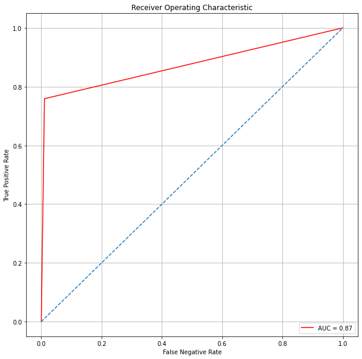

```
L'aire sous la courbe ROC :  0.8741720968629235

------------------------- 3. Learning curve : -------------------------------------------
```

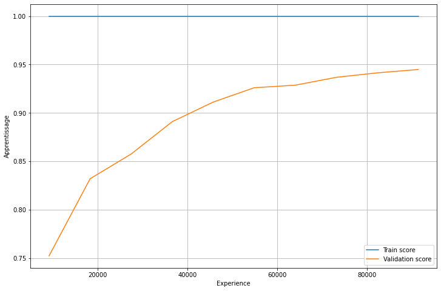

```python
evaluation(first_model, X_train, X_test)
```

**Résultats :**

- Recall : 0.76
- Precision : 0.85
- ROC : 0,874
- Learning curve : 94%

**Conclusion**

A présent, nous allons procéder à une sélection de variables.

## Feature Selection

### Feature importance

Trop de variables risque d'affecter un modèle de façon négative. De plus, un estimateur a besoin de variables qui varient en fonction de la TARGET. Par conséquent, les variables qui se caractérisent par une faible variance risquent de dégrader les performances de notre modèle. Nous allons essayer de les identifier.

Le modèle `RandomForestClassifier()` utilise des arbres de décision. Il est donc capable d'identifier les variables les plus importantes. Ci-dessous une fonction permettant de classer les features en fonction de leur importance :

```python
def select_variables(model, X, y) :
    model.fit(X, y)

    pd.DataFrame(model.feature_importances_, index= X.columns).plot.bar(figsize=(70,8))
    plt.xticks(rotation=45,
            horizontalalignment='right',
            fontweight='light',
            fontsize='small')
    plt.show()
```

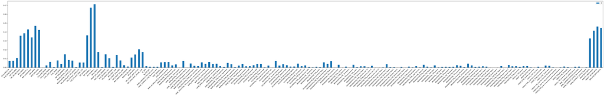

```python
select_variables(RandomForestClassifier(random_state=0), X_train, y_train)
```

Un grand nombre de features ne semblent pas utiles. Identifions celles les plus pertinentes à l'aide de l'outil `feature_importances_` de `RandomForestClassifier` :

```python
forest = RandomForestClassifier(random_state=0, n_jobs=-1)
forest.fit(X_train, y_train)
```

```
RandomForestClassifier(n_jobs=-1, random_state=0)
```

```python
def feature_importances (df):
    importances = forest.feature_importances_
    forest_importances = pd.Series(importances, index=df.columns)
    std = np.std([tree.feature_importances_ for tree in forest.estimators_], axis=0)

    fig, (ax1, ax2) = plt.subplots(nrows=1, ncols=2, figsize=(12,10))
    #forest_importances.plot.bar(yerr=std, ax=ax)
    forest_importances.nlargest(20).plot(kind='barh', color=['orange', 'violet', 'red'], ax=ax1)
    ax1.set_title("Top 20 features")
    ax1.set_ylabel("% d'influence")

    forest_importances.nsmallest(20).plot(kind='barh', color=['green', 'blue', 'cyan'], ax=ax2)
    ax2.set_title("Bottom 20 features")
    ax2.set_ylabel("% d'influence")
    fig.tight_layout()
```

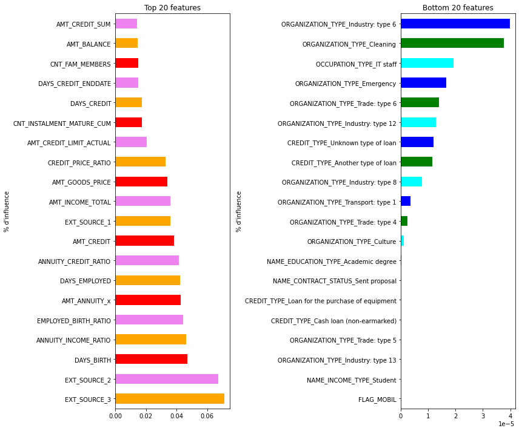

```python
feature_importances(X_train)
```

Nous remarquons que :

- les variables EXT_SOURCE_X sortent du lot
- les variables métier que nous venons de créer et ajouter manuellement ont un poids assez important par rapport aux autres features.

**Modélisation n°3 : feature selection**

```python
best_features = [
'EXT_SOURCE_3',
'EXT_SOURCE_2',
'DAYS_BIRTH',
'AMT_ANNUITY_x',
'DAYS_EMPLOYED',
'AMT_CREDIT',
'AMT_INCOME_TOTAL',
'CREDIT_PRICE_RATIO',
'AMT_GOODS_PRICE',
'EXT_SOURCE_1',
'DAYS_CREDIT',
'CNT_INSTALMENT_MATURE_CUM',
'DAYS_CREDIT_ENDDATE',
'AMT_CREDIT_SUM',
'AMT_CREDIT_LIMIT_ACTUAL',
'AMT_BALANCE',
'MONTHS_BALANCE',
'DAYS_ENDDATE_FACT',
'CNT_FAM_MEMBERS',
'AMT_CREDIT_SUM_DEBT'
]

X_train_best = X_train[best_features]
X_test_best = X_test[best_features]

shape_check(X_train_best, X_test_best)
```

```
Training set shape :  (121828, 20)
Testing set shape :  (30457, 20)
```

```
------------------------- 1. Matrice de confusion -------------------------------------------

[[27948   323]
 [  449  1737]]


              precision    recall  f1-score   support

         0.0       0.98      0.99      0.99     28271
         1.0       0.84      0.79      0.82      2186

    accuracy                           0.97     30457
   macro avg       0.91      0.89      0.90     30457
weighted avg       0.97      0.97      0.97     30457


------------------------- 2. Courbe ROC : -------------------------------------------
```

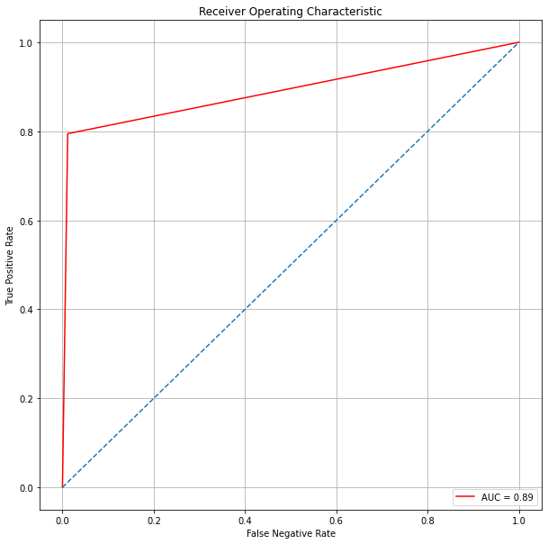

```
L'aire sous la courbe ROC :  0.891588438755564

------------------------- 3. Learning curve : -------------------------------------------
```

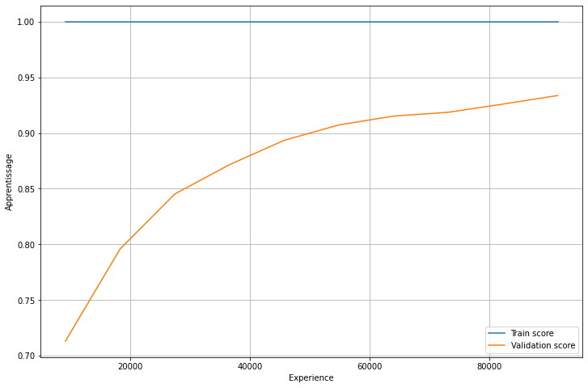

```python
evaluation(first_model, X_train_best, X_test_best)
```

**Résultats :**

- Recall : 0.79
- Precision : 0.84
- ROC : 0,891
- Learning curve : 94%

**Conclusion**

Les résultats sont très bons.

Nous venons de voir qu'un grand nombre de features ont un très faible impact sur l'apprentissage. Nous allons à présent comparer ce résultat avec d'autres méthodes de sélection de variables.

### Select From Model

SelectFromModel entraîne un estimateur puis sélectionne les variables les plus importantes pour cet estimateur.

```python
selector_model = SelectFromModel(SGDClassifier(random_state=0), threshold=7)
selector_model.fit(X_train, y_train)
```

```
SelectFromModel(estimator=SGDClassifier(random_state=0), threshold=7)
```

```python
#selector_model.estimator_.coef_
```

```python
np.array(X_train.columns)[selector_model.get_support()]
```

```
array(['FLAG_OWN_CAR', 'FLAG_OWN_REALTY', 'CNT_CHILDREN',
       'AMT_INCOME_TOTAL', 'AMT_CREDIT', 'AMT_ANNUITY_x',
       'AMT_GOODS_PRICE', 'DAYS_BIRTH', 'DAYS_EMPLOYED', 'FLAG_MOBIL',
       'FLAG_EMP_PHONE', 'FLAG_WORK_PHONE', 'FLAG_CONT_MOBILE',
       'FLAG_PHONE', 'CNT_FAM_MEMBERS', 'REGION_RATING_CLIENT',
       'REGION_RATING_CLIENT_W_CITY', 'EXT_SOURCE_1', 'EXT_SOURCE_2',
       'EXT_SOURCE_3', 'DAYS_CREDIT', 'CREDIT_DAY_OVERDUE',
       'DAYS_CREDIT_ENDDATE', 'DAYS_ENDDATE_FACT', 'AMT_CREDIT_SUM',
       'AMT_CREDIT_SUM_DEBT', 'AMT_CREDIT_SUM_LIMIT',
       'AMT_CREDIT_SUM_OVERDUE', 'MONTHS_BALANCE', 'AMT_BALANCE',
       'AMT_CREDIT_LIMIT_ACTUAL', 'CNT_INSTALMENT_MATURE_CUM', 'SK_DPD',
       'SK_DPD_DEF', 'NAME_CONTRACT_TYPE_Cash loans', 'CODE_GENDER_F',
       'CODE_GENDER_M', 'NAME_INCOME_TYPE_Commercial associate',
       'NAME_INCOME_TYPE_Pensioner', 'NAME_INCOME_TYPE_Working',
       'NAME_EDUCATION_TYPE_Higher education',
       'NAME_EDUCATION_TYPE_Secondary / secondary special',
       'NAME_FAMILY_STATUS_Married', 'NAME_FAMILY_STATUS_Widow',
       'NAME_HOUSING_TYPE_House / apartment',
       'NAME_HOUSING_TYPE_Municipal apartment',
       'NAME_HOUSING_TYPE_With parents', 'OCCUPATION_TYPE_Accountants',
       'OCCUPATION_TYPE_Drivers', 'OCCUPATION_TYPE_High skill tech staff',
       'OCCUPATION_TYPE_Laborers',
       'ORGANIZATION_TYPE_Business Entity Type 1',
       'ORGANIZATION_TYPE_Business Entity Type 2',
       'ORGANIZATION_TYPE_Business Entity Type 3',
       'ORGANIZATION_TYPE_Construction',
       'ORGANIZATION_TYPE_Industry: type 3', 'ORGANIZATION_TYPE_Medicine',
       'ORGANIZATION_TYPE_Other', 'CREDIT_ACTIVE_Active',
       'CREDIT_TYPE_Consumer credit', 'NAME_CONTRACT_STATUS_Active',
       'CREDIT_PRICE_RATIO', 'EMPLOYED_BIRTH_RATIO'], dtype=object)
```

```python
informative_features=[
       'FLAG_OWN_CAR', 'FLAG_OWN_REALTY', 'CNT_CHILDREN',
       'AMT_INCOME_TOTAL', 'AMT_CREDIT', 'AMT_ANNUITY_x',
       'AMT_GOODS_PRICE', 'DAYS_BIRTH', 'DAYS_EMPLOYED', 'FLAG_EMP_PHONE',
       'FLAG_WORK_PHONE', 'CNT_FAM_MEMBERS', 'REGION_RATING_CLIENT',
       'REGION_RATING_CLIENT_W_CITY', 'EXT_SOURCE_1', 'EXT_SOURCE_2',
       'EXT_SOURCE_3', 'DAYS_CREDIT', 'CREDIT_DAY_OVERDUE',
       'DAYS_CREDIT_ENDDATE', 'DAYS_ENDDATE_FACT', 'AMT_CREDIT_SUM',
       'AMT_CREDIT_SUM_DEBT', 'AMT_CREDIT_SUM_LIMIT',
       'AMT_CREDIT_SUM_OVERDUE', 'MONTHS_BALANCE', 'AMT_BALANCE',
       'AMT_CREDIT_LIMIT_ACTUAL', 'CNT_INSTALMENT_MATURE_CUM', 'SK_DPD',
       'SK_DPD_DEF', 'CODE_GENDER_F', 'CODE_GENDER_M',
       'NAME_INCOME_TYPE_Commercial associate',
       'NAME_INCOME_TYPE_Pensioner', 'NAME_INCOME_TYPE_Working',
       'NAME_EDUCATION_TYPE_Higher education',
       'NAME_EDUCATION_TYPE_Secondary / secondary special',
       'NAME_FAMILY_STATUS_Married', 'NAME_FAMILY_STATUS_Widow',
       'NAME_HOUSING_TYPE_House / apartment',
       'NAME_HOUSING_TYPE_With parents', 'OCCUPATION_TYPE_Accountants',
       'OCCUPATION_TYPE_Drivers', 'OCCUPATION_TYPE_High skill tech staff',
       'OCCUPATION_TYPE_Laborers', 'OCCUPATION_TYPE_Managers',
       'ORGANIZATION_TYPE_Business Entity Type 1',
       'ORGANIZATION_TYPE_Business Entity Type 3',
       'ORGANIZATION_TYPE_Industry: type 3', 'ORGANIZATION_TYPE_Medicine',
       'ORGANIZATION_TYPE_Other', 'ORGANIZATION_TYPE_Transport: type 2',
       'CREDIT_ACTIVE_Active', 'CREDIT_ACTIVE_Closed',
       'CREDIT_TYPE_Microloan', 'EMPLOYED_BIRTH_RATIO']

X_train_ft = X_train[informative_features]
X_test_ft = X_test[informative_features]


shape_check(X_train_ft, X_test_ft)
```

```
Training set shape :  (121828, 57)
Testing set shape :  (30457, 57)
```

```
------------------------- 1. Matrice de confusion -------------------------------------------

[[28009   262]
 [  441  1745]]


              precision    recall  f1-score   support

         0.0       0.98      0.99      0.99     28271
         1.0       0.87      0.80      0.83      2186

    accuracy                           0.98     30457
   macro avg       0.93      0.89      0.91     30457
weighted avg       0.98      0.98      0.98     30457


------------------------- 2. Courbe ROC : -------------------------------------------
```

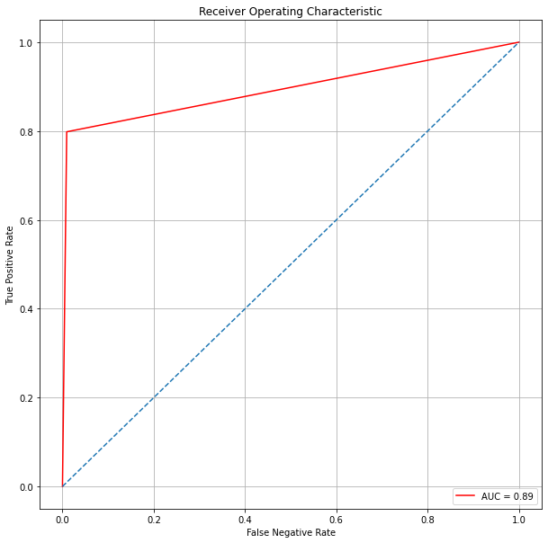

```
L'aire sous la courbe ROC :  0.8944971089672129

------------------------- 3. Learning curve : -------------------------------------------
```

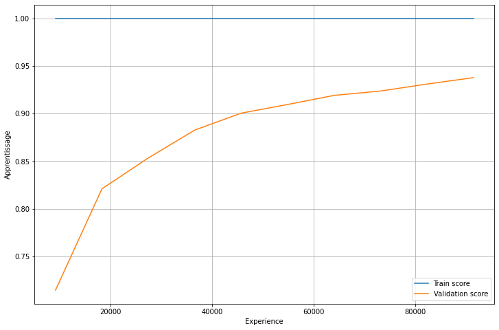

```python
evaluation(first_model, X_train_ft, X_test_ft)
```

**Résultats :**

- Recall : 0.80
- Precision : 0.87
- ROC : 0,894
- Learning curve : 94%

**Conclusion**

Cette façon de sélectionner les features a permis d'avoir de meilleurs résultats. Comparons-les avec l'outil `SelectKBest`.

### SelectKBest - test de dépendance

SelectKBest sélectionne les K variables X dont le score du test de dépendance (ici Chi2) avec y est le plus élevé.

Le sélecteur `SelectKBest` permet de sélectionner les variables puis de supprimer toutes les variables à l'exception des `k` plus élevées. Nous allons modifier la valeur `k` afin de retrouver le nombre de features les plus pertinentes :

```python
from sklearn.feature_selection import SelectKBest, chi2, f_classif
```

```python
pipeline_first = make_pipeline(SelectKBest(f_classif, k=10),
                      DecisionTreeClassifier(class_weight='balanced', random_state=0))
```

```
------------------------- 1. Matrice de confusion -------------------------------------------

[[27977   294]
 [  652  1534]]


              precision    recall  f1-score   support

         0.0       0.98      0.99      0.98     28271
         1.0       0.84      0.70      0.76      2186

    accuracy                           0.97     30457
   macro avg       0.91      0.85      0.87     30457
weighted avg       0.97      0.97      0.97     30457


------------------------- 2. Courbe ROC : -------------------------------------------
```

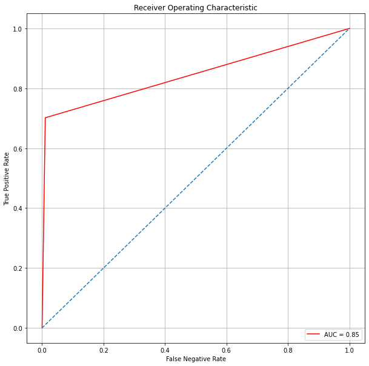

```
L'aire sous la courbe ROC :  0.8456694928509045

------------------------- 3. Learning curve : -------------------------------------------
```

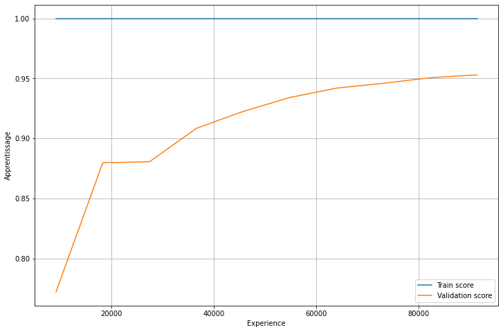

```python
evaluation(pipeline_first, X_train, X_test)
```

**Résultats :**

- Recall : 0.70
- Precision : 0.84
- ROC : 0,845
- Learning curve : 96%

**Conclusion**

```python
pipeline_third = make_pipeline(SelectKBest(f_classif, k=30),
                      DecisionTreeClassifier(class_weight='balanced', random_state=0))
```

```
------------------------- 1. Matrice de confusion -------------------------------------------

[[27975   296]
 [  577  1609]]


              precision    recall  f1-score   support

         0.0       0.98      0.99      0.98     28271
         1.0       0.84      0.74      0.79      2186

    accuracy                           0.97     30457
   macro avg       0.91      0.86      0.89     30457
weighted avg       0.97      0.97      0.97     30457


------------------------- 2. Courbe ROC : -------------------------------------------
```

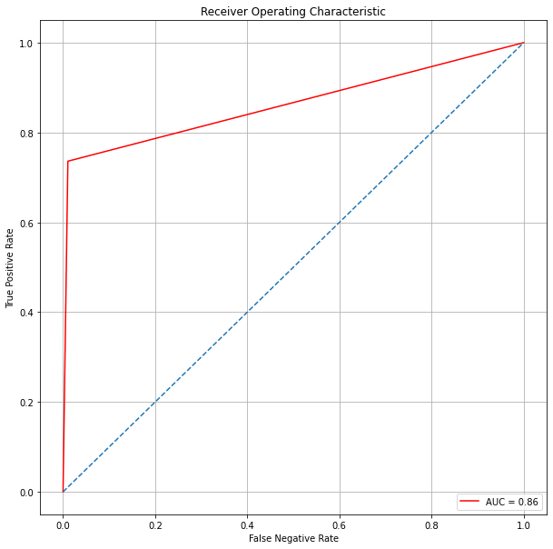

```
L'aire sous la courbe ROC :  0.8627887412260689

------------------------- 3. Learning curve : -------------------------------------------
```

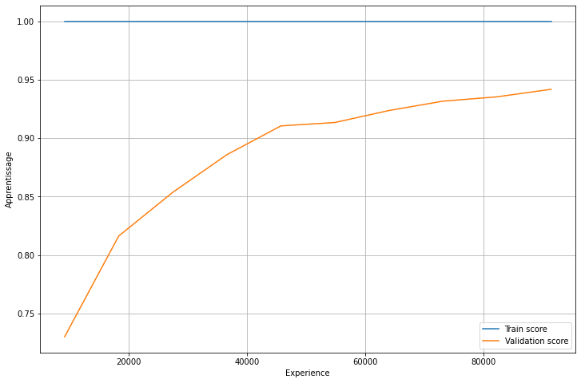

```python
evaluation(pipeline_third, X_train, X_test)
```

**Résultats :**

- Recall : 0.74
- Precision : 0.84
- ROC : 0,862
- Learning curve : 94%

**Conclusion**

Le `k` défini à `30` a permis d'avoir de très bons résultats également. Comparons-les avec l'outil `SelectKBest`.

```python
pipeline_first = make_pipeline(SelectKBest(f_classif, k=50),
                      DecisionTreeClassifier(class_weight='balanced', random_state=0))
```

```
------------------------- 1. Matrice de confusion -------------------------------------------

[[27835   436]
 [  600  1586]]


              precision    recall  f1-score   support

         0.0       0.98      0.98      0.98     28271
         1.0       0.78      0.73      0.75      2186

    accuracy                           0.97     30457
   macro avg       0.88      0.86      0.87     30457
weighted avg       0.96      0.97      0.97     30457


------------------------- 2. Courbe ROC : -------------------------------------------
```

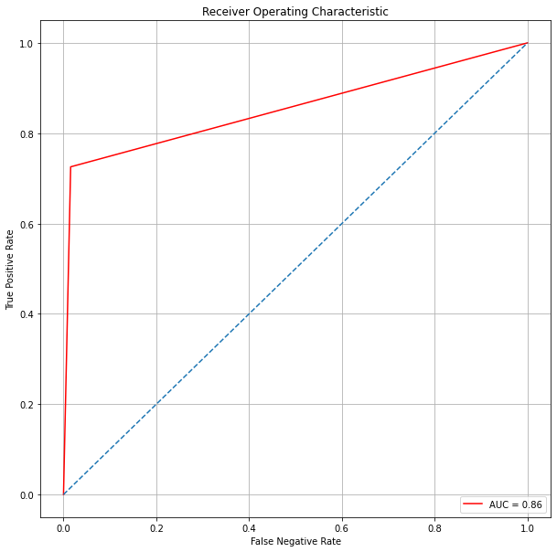

```
L'aire sous la courbe ROC :  0.855051955483917

------------------------- 3. Learning curve : -------------------------------------------
```

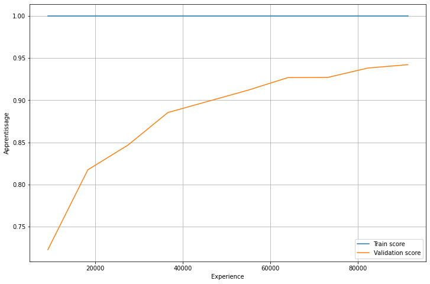

```python
evaluation(pipeline_first, X_train, X_test)
```

**Résultats :**

- Recall : 0.73
- Precision : 0.78
- ROC : 0,855
- Learning curve : 94%

**Conclusion**

Le nombre de features `k=50` a donné de bons résultats, mais moins bons que la sélection de features avec `feature_importances_` de `RandomForestClassifier()`.

```python
selector_kbest = SelectKBest(f_classif, k=50)
selector_kbest.fit(X_train, y_train)
```

```
SelectKBest(k=50)
```

```python
np.array(X_train.columns)[selector_kbest.get_support()]
```

```
array(['FLAG_OWN_CAR', 'CNT_CHILDREN', 'AMT_CREDIT', 'AMT_GOODS_PRICE',
       'DAYS_BIRTH', 'DAYS_EMPLOYED', 'FLAG_EMP_PHONE', 'FLAG_WORK_PHONE',
       'CNT_FAM_MEMBERS', 'REGION_RATING_CLIENT',
       'REGION_RATING_CLIENT_W_CITY', 'EXT_SOURCE_1', 'EXT_SOURCE_2',
       'EXT_SOURCE_3', 'DAYS_CREDIT', 'DAYS_ENDDATE_FACT',
       'AMT_CREDIT_SUM_DEBT', 'MONTHS_BALANCE', 'AMT_BALANCE',
       'AMT_CREDIT_LIMIT_ACTUAL', 'CNT_INSTALMENT_MATURE_CUM',
       'NAME_CONTRACT_TYPE_Cash loans',
       'NAME_CONTRACT_TYPE_Revolving loans', 'CODE_GENDER_F',
       'CODE_GENDER_M', 'NAME_INCOME_TYPE_Pensioner',
       'NAME_INCOME_TYPE_Working', 'NAME_EDUCATION_TYPE_Higher education',
       'NAME_EDUCATION_TYPE_Secondary / secondary special',
       'NAME_FAMILY_STATUS_Widow', 'NAME_HOUSING_TYPE_House / apartment',
       'NAME_HOUSING_TYPE_Rented apartment',
       'NAME_HOUSING_TYPE_With parents', 'OCCUPATION_TYPE_Accountants',
       'OCCUPATION_TYPE_Drivers', 'OCCUPATION_TYPE_High skill tech staff',
       'OCCUPATION_TYPE_Low-skill Laborers',
       'ORGANIZATION_TYPE_Business Entity Type 1',
       'ORGANIZATION_TYPE_Construction',
       'ORGANIZATION_TYPE_Industry: type 3',
       'ORGANIZATION_TYPE_Industry: type 9', 'ORGANIZATION_TYPE_Other',
       'ORGANIZATION_TYPE_Police', 'ORGANIZATION_TYPE_Religion',
       'ORGANIZATION_TYPE_Services', 'CREDIT_ACTIVE_Active',
       'CREDIT_ACTIVE_Closed', 'CREDIT_TYPE_Microloan',
       'CREDIT_PRICE_RATIO', 'EMPLOYED_BIRTH_RATIO'], dtype=object)
```

## 3.8 Dataset final

Suite à nos analyses, nous pouvons à présent créer un nouveau jeu de données d'entraînement et un nouveau jeu de données de test dont on se servira pour la modélisation :

```python
very_best_features=[
      'FLAG_OWN_REALTY', 'CNT_CHILDREN', 'AMT_CREDIT', 'AMT_GOODS_PRICE',
       'DAYS_BIRTH', 'DAYS_EMPLOYED', 'FLAG_EMP_PHONE', 'FLAG_WORK_PHONE',
       'CNT_FAM_MEMBERS', 'REGION_RATING_CLIENT',
       'REGION_RATING_CLIENT_W_CITY', 'EXT_SOURCE_1', 'EXT_SOURCE_2',
       'EXT_SOURCE_3', 'DAYS_CREDIT', 'DAYS_ENDDATE_FACT',
       'AMT_CREDIT_SUM_DEBT', 'MONTHS_BALANCE', 'AMT_BALANCE',
       'AMT_CREDIT_LIMIT_ACTUAL', 'CNT_INSTALMENT_MATURE_CUM',
       'NAME_CONTRACT_TYPE_Cash loans',
       'NAME_CONTRACT_TYPE_Revolving loans', 'CODE_GENDER_F',
       'CODE_GENDER_M', 'NAME_INCOME_TYPE_Pensioner',
       'NAME_INCOME_TYPE_Working', 'NAME_EDUCATION_TYPE_Higher education',
       'NAME_EDUCATION_TYPE_Secondary / secondary special',
       'NAME_FAMILY_STATUS_Widow', 'NAME_HOUSING_TYPE_House / apartment',
       'NAME_HOUSING_TYPE_Office apartment',
       'NAME_HOUSING_TYPE_Rented apartment',
       'NAME_HOUSING_TYPE_With parents', 'OCCUPATION_TYPE_Accountants',
       'OCCUPATION_TYPE_Drivers', 'OCCUPATION_TYPE_High skill tech staff',
       'OCCUPATION_TYPE_Low-skill Laborers',
       'ORGANIZATION_TYPE_Business Entity Type 1',
       'ORGANIZATION_TYPE_Industry: type 3', 'ORGANIZATION_TYPE_Other',
       'ORGANIZATION_TYPE_Police', 'ORGANIZATION_TYPE_Realtor',
       'ORGANIZATION_TYPE_Transport: type 2', 'CREDIT_ACTIVE_Active',
       'CREDIT_ACTIVE_Closed', 'CREDIT_TYPE_Consumer credit',
       'CREDIT_TYPE_Microloan', 'CREDIT_PRICE_RATIO',
       'EMPLOYED_BIRTH_RATIO']

X_train_final = X_train[very_best_features]
X_test_final = X_test[very_best_features]


shape_check(X_train_final, X_test_final)
```

```
Training set shape :  (121828, 50)
Testing set shape :  (30457, 50)
```

```python
X_train = X_train_final.copy()
```

```python
X_train.head()
```

|  | FLAG_OWN_REALTY | CNT_CHILDREN | AMT_CREDIT | AMT_GOODS_PRICE | DAYS_BIRTH | DAYS_EMPLOYED | FLAG_EMP_PHONE | FLAG_WORK_PHONE | CNT_FAM_MEMBERS | REGION_RATING_CLIENT | REGION_RATING_CLIENT_W_CITY | EXT_SOURCE_1 | EXT_SOURCE_2 | EXT_SOURCE_3 | DAYS_CREDIT | DAYS_ENDDATE_FACT | AMT_CREDIT_SUM_DEBT | MONTHS_BALANCE | AMT_BALANCE | AMT_CREDIT_LIMIT_ACTUAL | CNT_INSTALMENT_MATURE_CUM | NAME_CONTRACT_TYPE_Cash loans | NAME_CONTRACT_TYPE_Revolving loans | CODE_GENDER_F | CODE_GENDER_M | NAME_INCOME_TYPE_Pensioner | NAME_INCOME_TYPE_Working | NAME_EDUCATION_TYPE_Higher education | NAME_EDUCATION_TYPE_Secondary / secondary special | … |
| --- | --- | --- | --- | --- | --- | --- | --- | --- | --- | --- | --- | --- | --- | --- | --- | --- | --- | --- | --- | --- | --- | --- | --- | --- | --- | --- | --- | --- | --- | --- |
| 0 | 1.0 | 0.0 | 1082214.0 | 945000.0 | 54.432877 | 2630.0 | 1.0 | 0.0 | 2.0 | 2.0 | 2.0 | 0.562626 | 0.670557 | 0.501075 | 2483.0 | -2176.0 | 0.0 | -11.0 | 147226.185 | 180000.0 | 62.0 | 1.0 | 0.0 | 0.0 | 1.0 | 0.0 | 0.0 | 0.0 | 1.0 | … |
| 1 | 1.0 | 3.0 | 444420.0 | 337500.0 | 33.778082 | 304.0 | 1.0 | 0.0 | 5.0 | 2.0 | 2.0 | 0.562626 | 0.632805 | 0.431192 | 361.0 | -951.0 | 6583.5 | -10.0 | 353819.295 | 630000.0 | 3.0 | 1.0 | 0.0 | 0.0 | 1.0 | 0.0 | 1.0 | 0.0 | 1.0 | … |
| 2 | 1.0 | 0.0 | 148500.0 | 148500.0 | 37.041096 | 5488.0 | 1.0 | 0.0 | 2.0 | 2.0 | 2.0 | 0.103595 | 0.355847 | 0.479449 | 1215.0 | -1026.0 | 0.0 | -32.0 | 95226.525 | 90000.0 | 12.0 | 1.0 | 0.0 | 1.0 | 0.0 | 0.0 | 1.0 | 0.0 | 1.0 | … |
| 3 | 1.0 | 0.0 | 797818.5 | 634500.0 | 43.219178 | 3022.0 | 1.0 | 1.0 | 1.0 | 2.0 | 2.0 | 0.816152 | 0.694765 | 0.812823 | 1872.0 | -67.0 | 0.0 | -67.0 | 0.000 | 112500.0 | 37.0 | 1.0 | 0.0 | 1.0 | 0.0 | 0.0 | 0.0 | 1.0 | 0.0 | … |
| 4 | 1.0 | 0.0 | 1262583.0 | 1102500.0 | 57.189041 | 13977.0 | 1.0 | 1.0 | 2.0 | 3.0 | 3.0 | 0.562626 | 0.360482 | 0.614414 | 747.0 | -951.0 | 883885.5 | -57.0 | 0.000 | 0.0 | 11.0 | 1.0 | 0.0 | 1.0 | 0.0 | 0.0 | 1.0 | 0.0 | 1.0 | … |

```python
X_test = X_test_final.copy()
```

```python
X_test.head()
```

|  | FLAG_OWN_REALTY | CNT_CHILDREN | AMT_CREDIT | AMT_GOODS_PRICE | DAYS_BIRTH | DAYS_EMPLOYED | FLAG_EMP_PHONE | FLAG_WORK_PHONE | CNT_FAM_MEMBERS | REGION_RATING_CLIENT | REGION_RATING_CLIENT_W_CITY | EXT_SOURCE_1 | EXT_SOURCE_2 | EXT_SOURCE_3 | DAYS_CREDIT | DAYS_ENDDATE_FACT | AMT_CREDIT_SUM_DEBT | MONTHS_BALANCE | AMT_BALANCE | AMT_CREDIT_LIMIT_ACTUAL | CNT_INSTALMENT_MATURE_CUM | NAME_CONTRACT_TYPE_Cash loans | NAME_CONTRACT_TYPE_Revolving loans | CODE_GENDER_F | CODE_GENDER_M | NAME_INCOME_TYPE_Pensioner | NAME_INCOME_TYPE_Working | NAME_EDUCATION_TYPE_Higher education | NAME_EDUCATION_TYPE_Secondary / secondary special | … |
| --- | --- | --- | --- | --- | --- | --- | --- | --- | --- | --- | --- | --- | --- | --- | --- | --- | --- | --- | --- | --- | --- | --- | --- | --- | --- | --- | --- | --- | --- | --- |
| 0 | 1.0 | 0.0 | 630000.0 | 630000.0 | 33.032877 | 3146.0 | 1.0 | 0.0 | 2.0 | 2.0 | 2.0 | 0.565970 | 0.492174 | 0.448962 | 919.0 | -959.0 | 305941.5 | -73.0 | 75162.015 | 135000.0 | 14.0 | 1.0 | 0.0 | 0.0 | 1.0 | 0.0 | 0.0 | 0.0 | 1.0 | … |
| 1 | 1.0 | 2.0 | 545040.0 | 450000.0 | 48.380822 | 6189.0 | 1.0 | 0.0 | 4.0 | 2.0 | 2.0 | 0.605981 | 0.663666 | 0.206779 | 840.0 | -959.0 | 912838.5 | -64.0 | 64760.535 | 67500.0 | 25.0 | 1.0 | 0.0 | 0.0 | 1.0 | 0.0 | 1.0 | 1.0 | 0.0 | … |
| 2 | 1.0 | 0.0 | 501435.0 | 414000.0 | 41.868493 | 5539.0 | 1.0 | 0.0 | 2.0 | 3.0 | 3.0 | 0.565970 | 0.627392 | 0.537070 | 1059.0 | -959.0 | 253584.0 | -5.0 | 0.000 | 450000.0 | 14.0 | 1.0 | 0.0 | 1.0 | 0.0 | 0.0 | 1.0 | 1.0 | 0.0 | … |
| 3 | 0.0 | 0.0 | 1288350.0 | 1125000.0 | 51.424658 | 10958.0 | 1.0 | 0.0 | 2.0 | 2.0 | 2.0 | 0.565970 | 0.537021 | 0.502878 | 570.0 | -959.0 | 172593.0 | -2.0 | 0.000 | 180000.0 | 44.0 | 1.0 | 0.0 | 1.0 | 0.0 | 0.0 | 0.0 | 1.0 | 0.0 | … |
| 4 | 0.0 | 0.0 | 545040.0 | 450000.0 | 51.115068 | 799.0 | 1.0 | 1.0 | 2.0 | 2.0 | 2.0 | 0.565970 | 0.376741 | 0.520898 | 735.0 | -959.0 | 444015.0 | -2.0 | 204075.810 | 270000.0 | 97.0 | 1.0 | 0.0 | 0.0 | 1.0 | 0.0 | 0.0 | 0.0 | 1.0 | … |

# 3.9 Rééquilibrage des classes

La classe minoritaire de la variable `TARGET` est celle qui nous intéresse le plus.

En d'autres termes, la capacité d'un modèle à prédire correctement l'étiquette de **classe minoritaire est plus importante** (`True Positives`) que celle de la classe majoritaire (`True Negatives`). Pour rappel, voici la répartition des données dans les classes :

```python
counter(y_train)
```

```
Class = 0.0, n = 113203 (92.9203467183242%)
Class = 1.0, n = 8625 (7.079653281675805%)
```

```python
counter(y_test)
```

```
Class = 0.0, n = 28271 (92.82266802377121%)
Class = 1.0, n = 2186 (7.177331976228782%)
```

Afin **d'éviter un biais et de mauvaises performances d'apprentissage** sur la classe minoritaire, il est possible d'effectuer un rééquilibrage des classes. Nous allons procéder à un undersampling et un oversampling et ensuite nous allons tester les résultats.

**RandomUnderSampler()**

```python
shape_check(X_train, X_test)
```

```
Training set shape :  (121828, 50)
Testing set shape :  (30457, 50)
```

```python
counter(y_train)
```

```
Class = 0.0, n = 113203 (92.9203467183242%)
Class = 1.0, n = 8625 (7.079653281675805%)
```

```python
undersample = RandomUnderSampler()

# transform the dataset
X_train_us, y_train_us = undersample.fit_resample(X_train, y_train)
X_test_us, y_test_us = undersample.fit_resample(X_test, y_test)
```

```python
shape_check(X_train_us, X_test_us)
```

```
Training set shape :  (17250, 50)
Testing set shape :  (4372, 50)
```

```python
counter(y_train_us)
```

```
Class = 0.0, n = 8625 (50.0%)
Class = 1.0, n = 8625 (50.0%)
```

```python
counter(y_test_us)
```

```
Class = 0.0, n = 2186 (50.0%)
Class = 1.0, n = 2186 (50.0%)
```

**Modélisation n°4 : undersampling**

Nous allons entraîner notre modèle suite aux transformations liées au rééquilibrage des classes.

```
------------------------- 1. Matrice de confusion -------------------------------------------

[[1946  240]
 [ 665 1521]]


              precision    recall  f1-score   support

         0.0       0.75      0.89      0.81      2186
         1.0       0.86      0.70      0.77      2186

    accuracy                           0.79      4372
   macro avg       0.80      0.79      0.79      4372
weighted avg       0.80      0.79      0.79      4372


------------------------- 2. Courbe ROC : -------------------------------------------
```

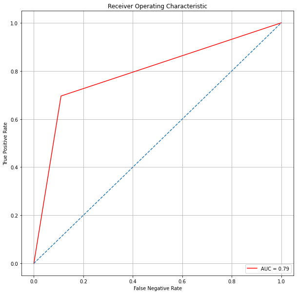

```
L'aire sous la courbe ROC :  0.7930009149130833

------------------------- 3. Learning curve : -------------------------------------------
```

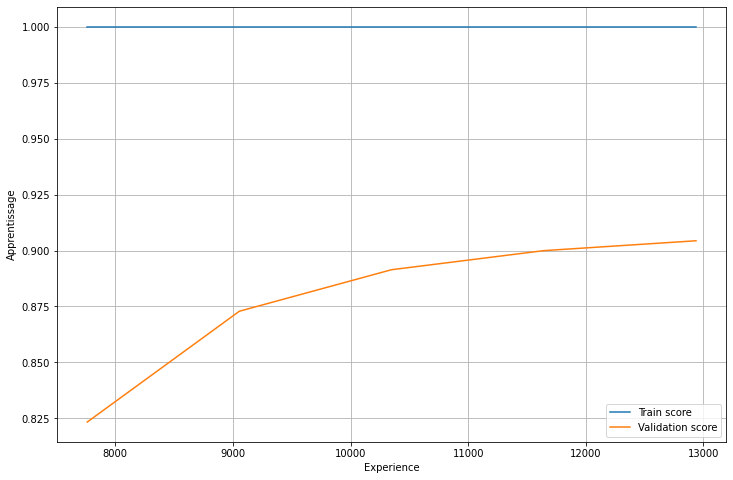

```python
evaluation(DecisionTreeClassifier(), X_train_us, X_test_us, y1=y_train_us, y2=y_test_us)
```

**Résultats :**

**SMOTE**

```python
oversample = SMOTE()

X_train_os, y_train_os = oversample.fit_resample(X_train, y_train)
X_test_os, y_test_os = oversample.fit_resample(X_test, y_test)
```

```python
shape_check(X_train_os, X_test_os)
```

```
Training set shape :  (226406, 50)
Testing set shape :  (56542, 50)
```

```python
counter(y_train_os)
```

```
Class = 0.0, n = 113203 (50.0%)
Class = 1.0, n = 113203 (50.0%)
```

```python
counter(y_test_os)
```

```
Class = 0.0, n = 28271 (50.0%)
Class = 1.0, n = 28271 (50.0%)
```

**Modélisation n°5 : oversampling**

```
------------------------- 1. Matrice de confusion -------------------------------------------

[[27703   568]
 [ 1893 26378]]


              precision    recall  f1-score   support

         0.0       0.94      0.98      0.96     28271
         1.0       0.98      0.93      0.96     28271

    accuracy                           0.96     56542
   macro avg       0.96      0.96      0.96     56542
weighted avg       0.96      0.96      0.96     56542


------------------------- 2. Courbe ROC : -------------------------------------------
```

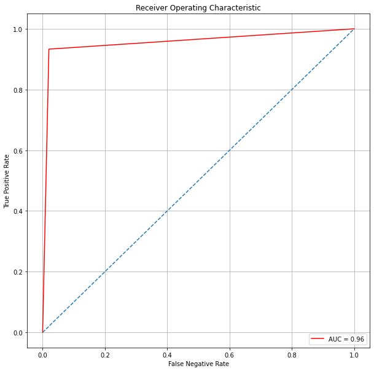

```
L'aire sous la courbe ROC :  0.9564748328676028

------------------------- 3. Learning curve : -------------------------------------------
```

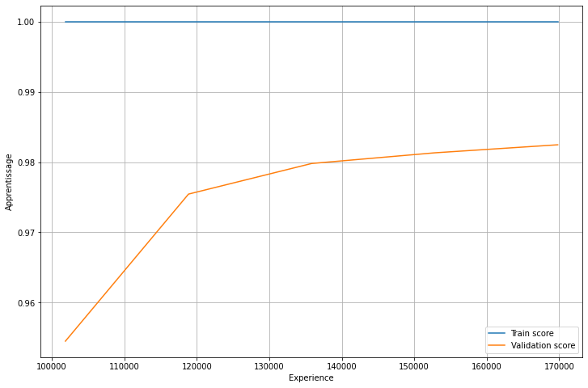

```python
evaluation(DecisionTreeClassifier(), X_train_os, X_test_os, y1=y_train_os, y2=y_test_os)
```

**Résultats :**

**Conclusion**

L'over-sampling permet d'avoir d'excellents résultats.

```python
shape_check(X_train_os, X_test_os)
```

```
Training set shape :  (226406, 50)
Testing set shape :  (56542, 50)
```

```python
y_train_os.shape, y_test_os.shape
```

```
((226406,), (56542,))
```

# 4. Comparaison et synthèse des résultats pour les modèles utilisés

## 4.1. Baseline

A présent, nous allons mettre en place un model naïf de classification `DummyClassifier`. Voici les stratégies envisageables :

- `stratified` : génère les prédictions en respectant la distribution de la classe du training set
- `most_frequent` : toujours prédit le label le plus fréquent du training set
- `prior` : toujours prédit la classe prioritaire
- `uniform` : génère des prédictions de façon uniforme et aléatoire
- `constant` : toujours prédit le même label indiqué par l'utilisateur

Notre modèle naïf adoptera les stratégies `most_frequent` et `uniform` :

```python
uniform_clf = DummyClassifier(strategy='uniform')
uniform_clf.fit(X_train, y_train)
y_uniform_pred = uniform_clf.predict(X_test)
```

```python
frequent_clf = DummyClassifier(strategy='most_frequent')
frequent_clf.fit(X_train, y_train)
y_freq_pred = frequent_clf.predict(X_test)
```

**Stratégie `uniform`**

```python
print("Uniform classification", uniform_clf.score(X_test, y_test))
```

```
Uniform classification 0.4987687559510129
```

```python
confusion_matrix(y_test, y_uniform_pred)
```

```
array([[14128, 14143],
       [ 1113,  1073]])
```

La stratégie `uniform` permet de donner les prédictions de façon trop égalitaire :

```
------------------------- 1. Matrice de confusion -------------------------------------------

[[14141 14130]
 [ 1133  1053]]


              precision    recall  f1-score   support

         0.0       0.93      0.50      0.65     28271
         1.0       0.07      0.48      0.12      2186

    accuracy                           0.50     30457
   macro avg       0.50      0.49      0.39     30457
weighted avg       0.86      0.50      0.61     30457


------------------------- 2. Courbe ROC : -------------------------------------------
```

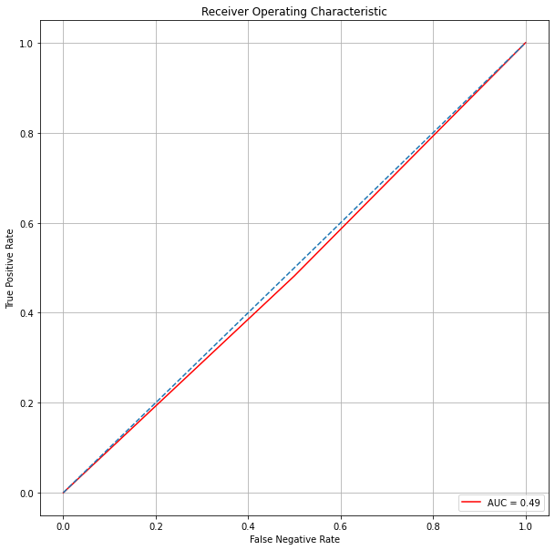

```
L'aire sous la courbe ROC :  0.4909481419911707

------------------------- 3. Learning curve : -------------------------------------------
```

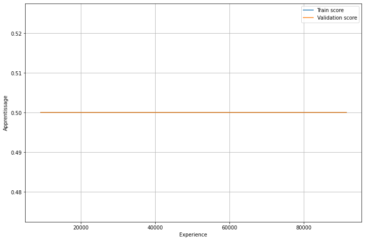

```python
evaluation(uniform_clf, X_train, X_test)
```

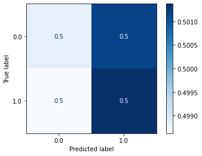

```python
plot_confusion_matrix(estimator=uniform_clf, X=X_test, y_true=y_test,normalize='true', cmap='Blues')
plt.show()
```

**Stratégie `most_frequent`**

```python
print("Predictions of the most frequent class :", frequent_clf.score(X_test, y_test))
```

```
Predictions of the most frequent class : 0.9282266802377122
```

```python
confusion_matrix(y_test, y_freq_pred)
```

```
array([[28271,     0],
       [ 2186,     0]])
```

```
------------------------- 1. Matrice de confusion -------------------------------------------

[[28271     0]
 [ 2186     0]]


              precision    recall  f1-score   support

         0.0       0.93      1.00      0.96     28271
         1.0       0.00      0.00      0.00      2186

    accuracy                           0.93     30457
   macro avg       0.46      0.50      0.48     30457
weighted avg       0.86      0.93      0.89     30457


------------------------- 2. Courbe ROC : -------------------------------------------
```

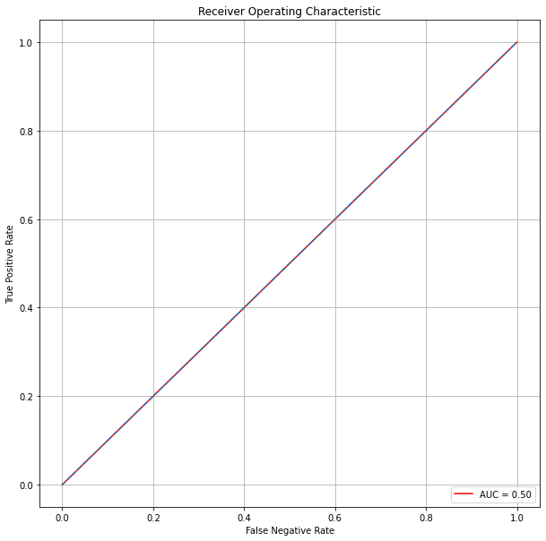

```
L'aire sous la courbe ROC :  0.5

------------------------- 3. Learning curve : -------------------------------------------
```

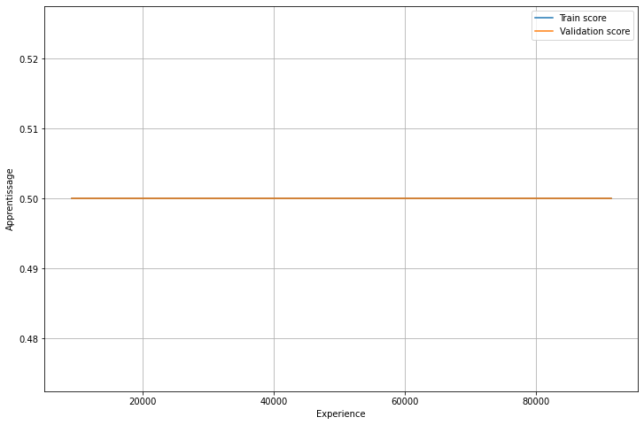

```python
evaluation(frequent_clf, X_train, X_test)
```

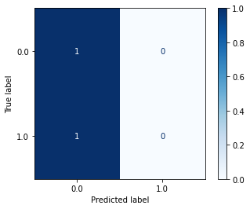

```python
plot_confusion_matrix(estimator=frequent_clf, X=X_test, y_true=y_test,normalize='true', cmap='Blues')
plt.show()
```

**Conclusions :**

Le comportement du `DummyClassifier` est complètement indépendant des données d'entraînement car il utilise une stratégie définie pour prédire le label.